# Travel Package Purchase Prediction

## Import necessary libraries

```python
# Library to suppress warnings or deprecation notes
import warnings
warnings.filterwarnings('ignore')

# Libraries to help with reading and manipulating data
import numpy as np
import pandas as pd

# Libraries to help with data visualization
import matplotlib.pyplot as plt
%matplotlib inline
import seaborn as sns

# Libraries to split data, impute missing values
from sklearn.model_selection import train_test_split
from sklearn.impute import SimpleImputer

# Libraries to import decision tree classifier and different ensemble classifiers
from sklearn.ensemble import BaggingClassifier
from sklearn.ensemble import RandomForestClassifier
from sklearn.ensemble import AdaBoostClassifier, GradientBoostingClassifier
from xgboost import XGBClassifier
from sklearn.ensemble import StackingClassifier
from sklearn.tree import DecisionTreeClassifier

# Libtune to tune model, get different metric scores
from sklearn import metrics
from sklearn.metrics import confusion_matrix, classification_report, accuracy_score, precision_score, recall_score, f1_score, roc_auc_score
from sklearn.model_selection import GridSearchCV
```

## Reading the dataset

```python
data = pd.read_excel('Tourism.xlsx')
```

```python
data.info()
```

```
<class 'pandas.core.frame.DataFrame'>
RangeIndex: 4888 entries, 0 to 4887
Data columns (total 20 columns):
 #   Column                    Non-Null Count  Dtype
---  ------                    --------------  -----
 0   CustomerID                4888 non-null   int64
 1   ProdTaken                 4888 non-null   int64
 2   Age                       4662 non-null   float64
 3   TypeofContact             4863 non-null   object
 4   CityTier                  4888 non-null   int64
 5   DurationOfPitch           4637 non-null   float64
 6   Occupation                4888 non-null   object
 7   Gender                    4888 non-null   object
 8   NumberOfPersonVisiting    4888 non-null   int64
 9   NumberOfFollowups         4843 non-null   float64
 10  ProductPitched            4888 non-null   object
 11  PreferredPropertyStar     4862 non-null   float64
 12  MaritalStatus             4888 non-null   object
 13  NumberOfTrips             4748 non-null   float64
 14  Passport                  4888 non-null   int64
 15  PitchSatisfactionScore    4888 non-null   int64
 16  OwnCar                    4888 non-null   int64
 17  NumberOfChildrenVisiting  4822 non-null   float64
 18  Designation               4888 non-null   object
 19  MonthlyIncome             4655 non-null   float64
dtypes: float64(7), int64(7), object(6)
memory usage: 763.9+ KB
```

### Fixing Datatypes

```python
# creating list of category columns that are not object type(int)
cat_cols = ["CityTier","ProdTaken","NumberOfPersonVisiting","NumberOfChildrenVisiting",
            "PreferredPropertyStar","Passport","PitchSatisfactionScore","OwnCar"]
data[cat_cols] = data[cat_cols].astype("category")
```

```python
# selecting all object datatypes and converting to category
cols = data.select_dtypes(["object"])
for i in cols.columns:
    data[i] = data[i].astype("category")

data.info()
```

```
<class 'pandas.core.frame.DataFrame'>
RangeIndex: 4888 entries, 0 to 4887
Data columns (total 20 columns):
 #   Column                    Non-Null Count  Dtype
---  ------                    --------------  -----
 0   CustomerID                4888 non-null   int64
 1   ProdTaken                 4888 non-null   category
 2   Age                       4662 non-null   float64
 3   TypeofContact             4863 non-null   category
 4   CityTier                  4888 non-null   category
 5   DurationOfPitch           4637 non-null   float64
 6   Occupation                4888 non-null   category
 7   Gender                    4888 non-null   category
 8   NumberOfPersonVisiting    4888 non-null   category
 9   NumberOfFollowups         4843 non-null   float64
 10  ProductPitched            4888 non-null   category
 11  PreferredPropertyStar     4862 non-null   category
 12  MaritalStatus             4888 non-null   category
 13  NumberOfTrips             4748 non-null   float64
 14  Passport                  4888 non-null   category
 15  PitchSatisfactionScore    4888 non-null   category
 16  OwnCar                    4888 non-null   category
 17  NumberOfChildrenVisiting  4822 non-null   category
 18  Designation               4888 non-null   category
 19  MonthlyIncome             4655 non-null   float64
dtypes: category(14), float64(5), int64(1)
memory usage: 298.4 KB
```

### Missing values

```python
data.drop(['CustomerID'],axis=1,inplace=True)
```

```python
data.isnull().sum()
```

```
ProdTaken                     0
Age                         226
TypeofContact                25
CityTier                      0
DurationOfPitch             251
Occupation                    0
Gender                        0
NumberOfPersonVisiting        0
NumberOfFollowups            45
ProductPitched                0
PreferredPropertyStar        26
MaritalStatus                 0
NumberOfTrips               140
Passport                      0
PitchSatisfactionScore        0
OwnCar                        0
NumberOfChildrenVisiting     66
Designation                   0
MonthlyIncome               233
dtype: int64
```

- 8 columns have missing values
- some can be replaced with median values

```python
#for float values
missing_values = data.select_dtypes(include=np.number).columns.tolist()
missing_values.remove('Age')
missing_values.remove('MonthlyIncome')
missing_values
```

```
['DurationOfPitch', 'NumberOfFollowups', 'NumberOfTrips']
```

```python
medianFiller = lambda x: x.fillna(x.median()) #replacing with the Median value
data[missing_values] = data[missing_values].apply(medianFiller,axis=0)
```

```python
#replace missing values with median income w.r.t the customer's designation
data["MonthlyIncome"] = data.groupby(['Designation'])['MonthlyIncome'].transform(lambda x: x.fillna(x.median()))
data["Age"] = data.groupby(['Designation'])['Age'].transform(lambda x: x.fillna(x.median()))
```

```python
cat_cols =  data.select_dtypes(['category'])
for i in cat_cols.columns:
    print(cat_cols[i].value_counts())
    print('-'*50)
    print('\n')
```

```
0    3968
1     920
Name: ProdTaken, dtype: int64
--------------------------------------------------


Self Enquiry       3444
Company Invited    1419
Name: TypeofContact, dtype: int64
--------------------------------------------------


1    3190
3    1500
2     198
Name: CityTier, dtype: int64
--------------------------------------------------


Salaried          2368
Small Business    2084
Large Business     434
Free Lancer          2
Name: Occupation, dtype: int64
--------------------------------------------------


Male       2916
Female     1817
Fe Male     155
Name: Gender, dtype: int64
--------------------------------------------------


3    2402
2    1418
4    1026
1      39
5       3
Name: NumberOfPersonVisiting, dtype: int64
```

[output cut: 48 more lines]

```
1.0    2080
2.0    1335
0.0    1082
3.0     325
Name: NumberOfChildrenVisiting, dtype: int64
--------------------------------------------------


Executive         1842
Manager           1732
Senior Manager     742
AVP                342
VP                 230
Name: Designation, dtype: int64
--------------------------------------------------
```

```python
#treating missing values in categorical variables
data['TypeofContact'] = data['TypeofContact'].fillna('Self Enquiry')
data['NumberOfChildrenVisiting'] = data['NumberOfChildrenVisiting'].fillna(1.0)
data['PreferredPropertyStar'] = data['PreferredPropertyStar'].fillna(3.0)
```

```python
#null values
data.isnull().sum()
```

```
ProdTaken                   0
Age                         0
TypeofContact               0
CityTier                    0
DurationOfPitch             0
Occupation                  0
Gender                      0
NumberOfPersonVisiting      0
NumberOfFollowups           0
ProductPitched              0
PreferredPropertyStar       0
MaritalStatus               0
NumberOfTrips               0
Passport                    0
PitchSatisfactionScore      0
OwnCar                      0
NumberOfChildrenVisiting    0
Designation                 0
MonthlyIncome               0
dtype: int64
```

```python
#theres an issue with female which needs to be corrected
data.Gender = data.Gender.replace('Fe Male','Female')
```

```python
data.Gender.value_counts()
```

```
Male      2916
Female    1972
Name: Gender, dtype: int64
```

```python
# summary of numerical columns
data.describe().T
```

|  | count | mean | std | min | 25% | 50% | 75% | max |
| --- | --- | --- | --- | --- | --- | --- | --- | --- |
| Age | 4888.0 | 37.429828 | 9.149822 | 18.0 | 31.0 | 36.0 | 43.00 | 61.0 |
| DurationOfPitch | 4888.0 | 15.362930 | 8.316166 | 5.0 | 9.0 | 13.0 | 19.00 | 127.0 |
| NumberOfFollowups | 4888.0 | 3.711129 | 0.998271 | 1.0 | 3.0 | 4.0 | 4.00 | 6.0 |
| NumberOfTrips | 4888.0 | 3.229746 | 1.822769 | 1.0 | 2.0 | 3.0 | 4.00 | 22.0 |
| MonthlyIncome | 4888.0 | 23546.843903 | 5266.279293 | 1000.0 | 20485.0 | 22413.5 | 25424.75 | 98678.0 |

```python
data.duplicated().sum()
```

```
141
```

```python
data.drop_duplicates(inplace=True)
```

```python
data.corr()
```

|  | Age | DurationOfPitch | NumberOfFollowups | NumberOfTrips | MonthlyIncome |
| --- | --- | --- | --- | --- | --- |
| Age | 1.000000 | -0.006826 | 0.008222 | 0.172964 | 0.469240 |
| DurationOfPitch | -0.006826 | 1.000000 | 0.016099 | 0.012480 | 0.002692 |
| NumberOfFollowups | 0.008222 | 0.016099 | 1.000000 | 0.133861 | 0.171718 |
| NumberOfTrips | 0.172964 | 0.012480 | 0.133861 | 1.000000 | 0.114079 |
| MonthlyIncome | 0.469240 | 0.002692 | 0.171718 | 0.114079 | 1.000000 |

### EDA

```python
# function to plot a boxplot and a histogram along the same scale.


def histogram_boxplot(data, feature, figsize=(10, 6), kde=False, bins=None):
    """
    Boxplot and histogram combined

    data: dataframe
    feature: dataframe column
    figsize: size of figure (default (12,7))
    kde: whether to show the density curve (default False)
    bins: number of bins for histogram (default None)
    """
    f2, (ax_box2, ax_hist2) = plt.subplots(
        nrows=2,  # Number of rows of the subplot grid= 2
        sharex=True,  # x-axis will be shared among all subplots
        gridspec_kw={"height_ratios": (0.25, 0.75)},
        figsize=figsize,
    )  # creating the 2 subplots
    sns.boxplot(
        data=data, x=feature, ax=ax_box2, showmeans=True, color="violet"
    )  # boxplot will be created and a triangle will indicate the mean value of the column
    sns.histplot(
        data=data, x=feature, kde=kde, ax=ax_hist2, bins=bins
    ) if bins else sns.histplot(
        data=data, x=feature, kde=kde, ax=ax_hist2
    )  # For histogram
    ax_hist2.axvline(
        data[feature].mean(), color="green", linestyle="--"
    )  # Add mean to the histogram
    ax_hist2.axvline(
        data[feature].median(), color="black", linestyle="-"
    )  # Add median to the histogram
```

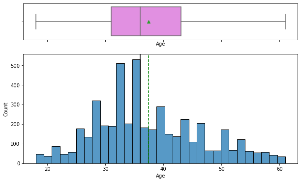

```python
# using defined function histogram_boxplot to plot the graph
histogram_boxplot(data,'Age')
```

- median age is about 36 and mean age 38
- doesnt contain any outlier
- age 30-40 are the most frequent

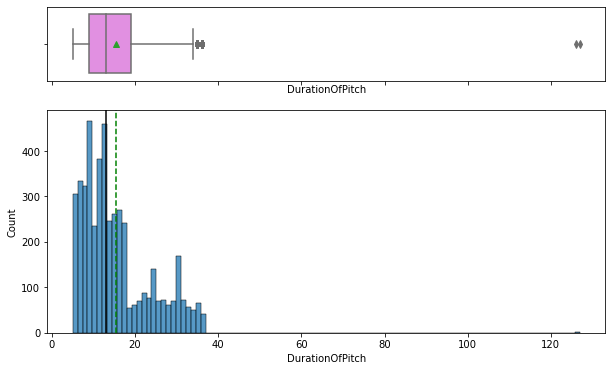

```python
# using defined function histogram_boxplot to plot the graph
histogram_boxplot(data,"DurationOfPitch")
```

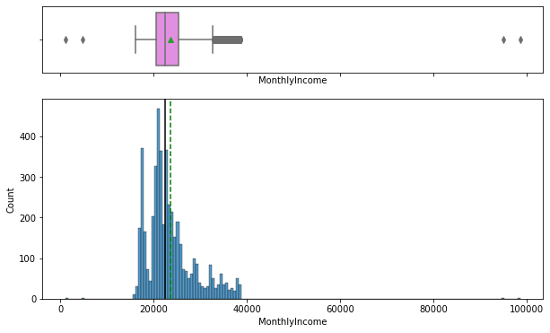

```python
# using defined function histogram_boxplot to plot the graph
histogram_boxplot(data,"MonthlyIncome")
```

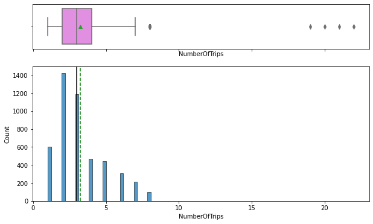

```python
histogram_boxplot(data,"NumberOfTrips")
```

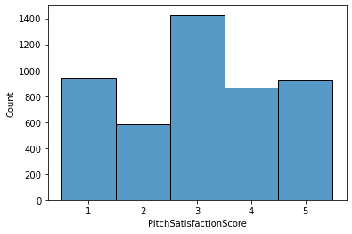

```python
sns.histplot(data=data, x='PitchSatisfactionScore')
```

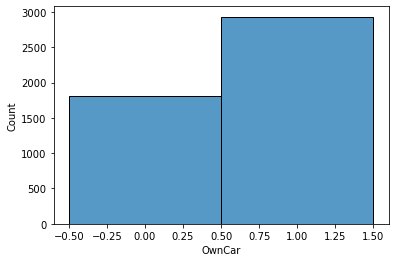

```python
sns.histplot(data=data, x='OwnCar')
```

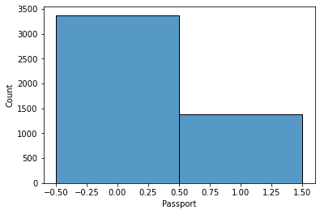

```python
sns.histplot(data=data, x='Passport')
```

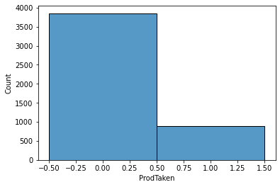

```python
sns.histplot(data=data, x='ProdTaken')
```

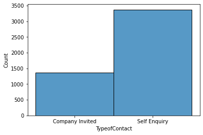

```python
sns.histplot(data=data, x='TypeofContact')
```

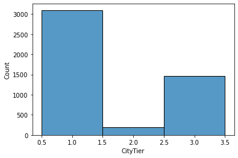

```python
sns.histplot(data=data, x='CityTier')
```

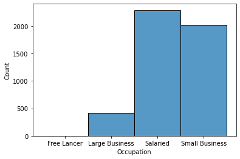

```python
sns.histplot(data=data, x='Occupation')
```

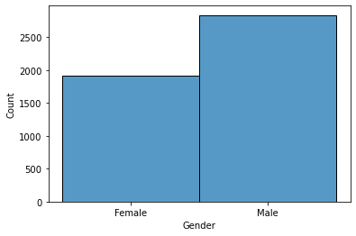

```python
sns.histplot(data=data, x='Gender')
```

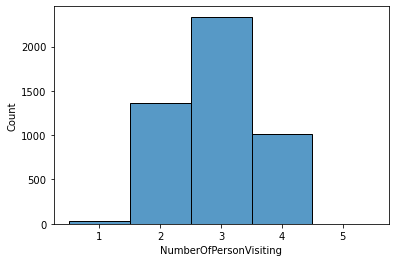

```python
sns.histplot(data=data, x='NumberOfPersonVisiting')
```

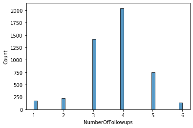

```python
sns.histplot(data=data, x='NumberOfFollowups')
```

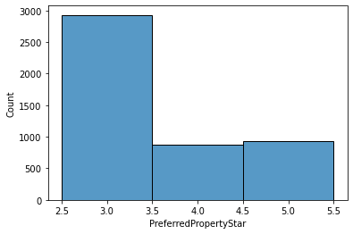

```python
sns.histplot(data=data, x='PreferredPropertyStar')
```

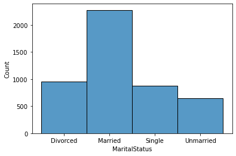

```python
sns.histplot(data=data, x='MaritalStatus')
```

- Married customers form the bulk of the data
- Divorced and Single coming second and third place.
- Unmarried customers with partners are least of the data.

### Bivariate analysis

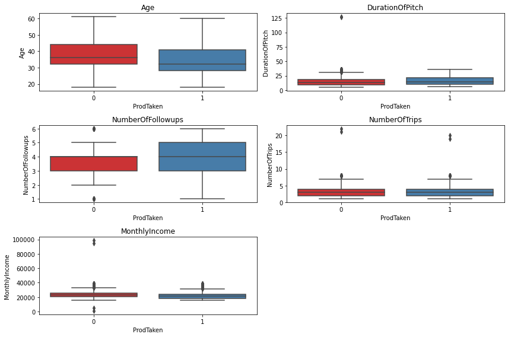

```python
# Comparing Numerical Var with ProdTaken
num_cols = data.select_dtypes(include=np.number).columns.tolist()

plt.figure(figsize=(12,8))
for i, variable in enumerate(num_cols):
                     plt.subplot(3,2,i+1)
                     sns.boxplot(data["ProdTaken"],data[variable],palette="Set1")
                     plt.tight_layout()
                     plt.title(variable)
plt.show()
```

- there are outliers in all except age
- mean age of those who purchased a product is less
- Cust who purchased the packages had an average of 4 followups
- no of trips is almost equal for both categories

```python
#Stacked plot of categorical variables with Personal Loans
def stacked_plot(x):
    sns.set(palette='magma')
    tab1 = pd.crosstab(x,data['ProdTaken'],margins=True)
    print(tab1)
    print('-'*120)
    tab = pd.crosstab(x,data['ProdTaken'],normalize='index')
    tab.plot(kind='bar',stacked=True,figsize=(10,5))
    plt.legend(loc='lower left', frameon=True)
    plt.legend(loc="upper left", bbox_to_anchor=(1,1))
    plt.ylabel('Percentage')
    plt.show()
```

```
ProdTaken           0    1   All
TypeofContact
Company Invited  1078  294  1372
Self Enquiry     2775  600  3375
All              3853  894  4747
------------------------------------------------------------------------------------------------------------------------
```

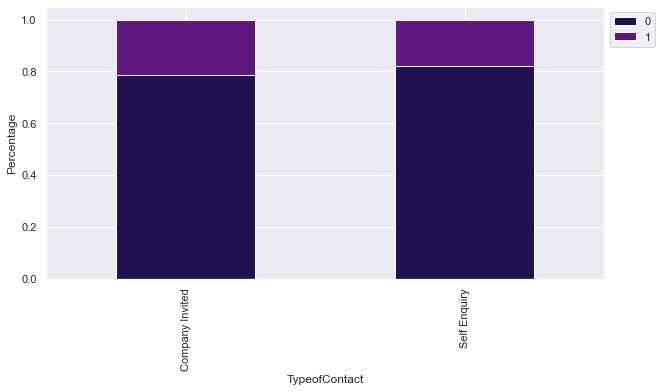

```python
stacked_plot(data.TypeofContact)
```

slightly More Customers with Company Invited contact have bought Travel Package compared to Customers with "Self Enquiry

```
ProdTaken          0    1   All
Occupation
Free Lancer        0    2     2
Large Business   306  118   424
Salaried        1893  400  2293
Small Business  1654  374  2028
All             3853  894  4747
------------------------------------------------------------------------------------------------------------------------
```

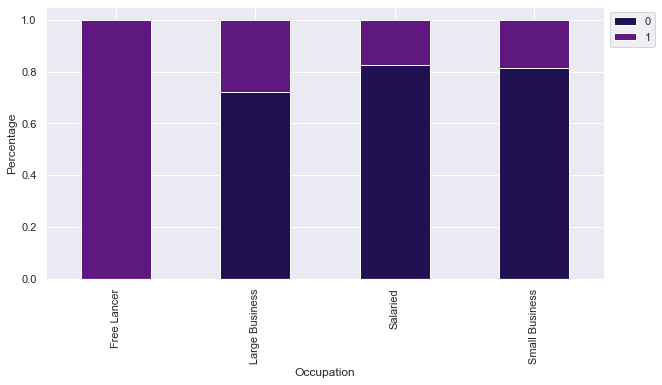

```python
stacked_plot(data.Occupation)
```

- free lancers have bought the most tickets, but at the same time there are only 2 samples meaning it doesnt say much about free lancers
- people with large scale businesses are more likely to buy tickets followed by small businesses then salaried.
- people with large businesses should be the most targeted

```
ProdTaken     0    1   All
Gender
Female     1580  332  1912
Male       2273  562  2835
All        3853  894  4747
------------------------------------------------------------------------------------------------------------------------
```

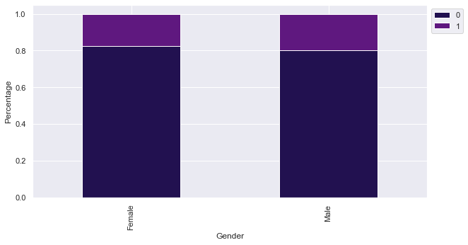

```python
stacked_plot(data.Gender)
```

- more males buy tickets comared to females
- the difference between them isnt so much

```
ProdTaken          0    1   All
Designation
AVP              308   16   324
Executive       1260  540  1800
Manager         1486  198  1684
Senior Manager   594  120   714
VP               205   20   225
All             3853  894  4747
------------------------------------------------------------------------------------------------------------------------
```

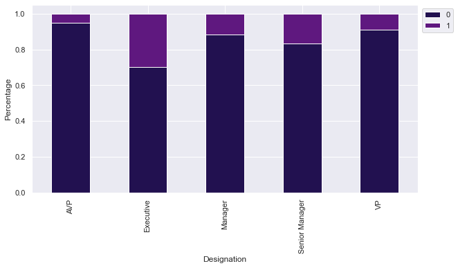

```python
stacked_plot(data.Designation)
```

- Executives are the most likely to buy tickets
- the least likely to buy are AVP and VP

```
ProdTaken     0    1   All
OwnCar
0          1463  352  1815
1          2390  542  2932
All        3853  894  4747
------------------------------------------------------------------------------------------------------------------------
```

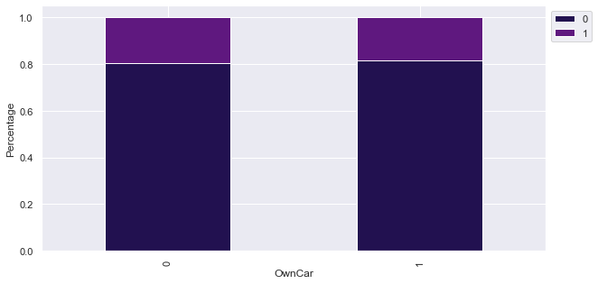

```python
stacked_plot(data.OwnCar)
```

- The number of customers who bought a product is fairly equal across both classes

```
ProdTaken                    0    1   All
NumberOfChildrenVisiting
0.0                        851  194  1045
1.0                       1688  386  2074
2.0                       1056  248  1304
3.0                        258   66   324
All                       3853  894  4747
------------------------------------------------------------------------------------------------------------------------
```

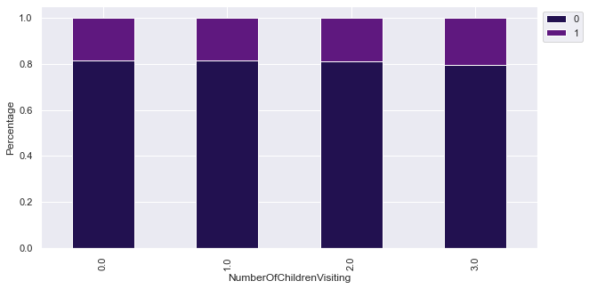

```python
stacked_plot(data.NumberOfChildrenVisiting)
```

```
ProdTaken     0    1   All
Passport
0          2958  414  3372
1           895  480  1375
All        3853  894  4747
------------------------------------------------------------------------------------------------------------------------
```

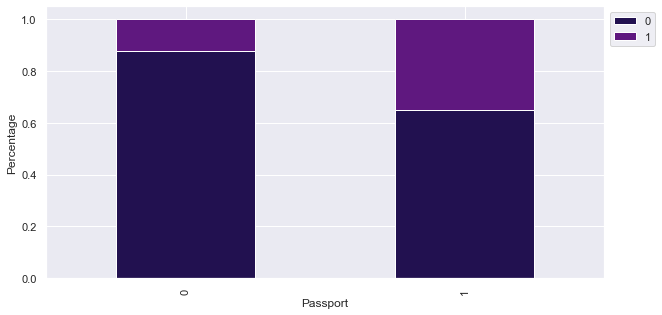

```python
stacked_plot(data.Passport)
```

- mostly people who who have passports tend to purchase products

```
ProdTaken                  0    1   All
PitchSatisfactionScore
1                        798  144   942
2                        498   88   586
3                       1123  304  1427
4                        709  160   869
5                        725  198   923
All                     3853  894  4747
------------------------------------------------------------------------------------------------------------------------
```

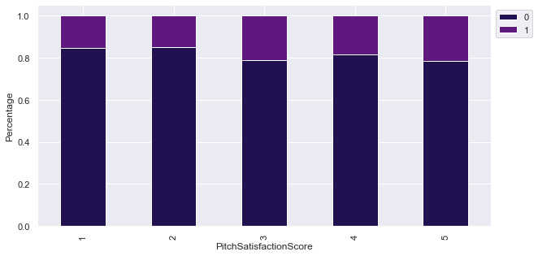

```python
stacked_plot(data.PitchSatisfactionScore)
```

- the number of customers who purchased any product is almost equal across all pitch scores.
- a high product pitch score doesnt guarantee purchase

```
ProdTaken         0    1   All
MaritalStatus
Divorced        826  124   950
Married        1965  314  2279
Single          578  297   875
Unmarried       484  159   643
All            3853  894  4747
------------------------------------------------------------------------------------------------------------------------
```

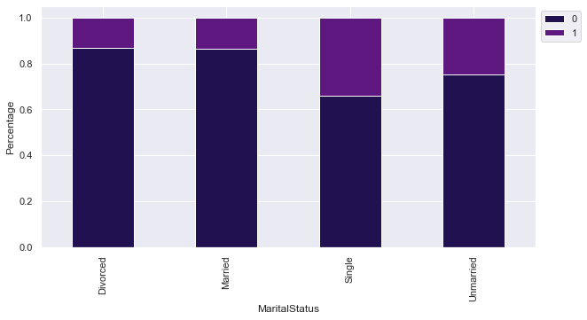

```python
stacked_plot(data.MaritalStatus)
```

```
ProdTaken                 0    1   All
PreferredPropertyStar
3.0                    2455  476  2931
4.0                     702  176   878
5.0                     696  242   938
All                    3853  894  4747
------------------------------------------------------------------------------------------------------------------------
```

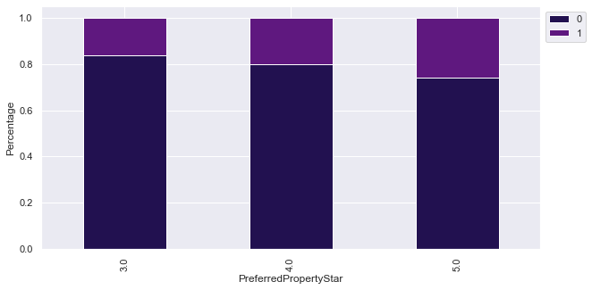

```python
stacked_plot(data.PreferredPropertyStar)
```

- majority of customers prefer a rating of 3 star
- the percentage of customers purchasing the products is comparitively less than customers who prefer a 4.0 and 5.0 star rated property.

```
ProdTaken          0    1   All
ProductPitched
Basic           1260  540  1800
Deluxe          1486  198  1684
King             205   20   225
Standard         594  120   714
Super Deluxe     308   16   324
All             3853  894  4747
------------------------------------------------------------------------------------------------------------------------
```

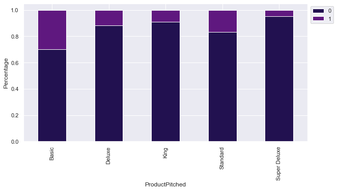

```python
stacked_plot(data.ProductPitched)
```

- Basic package is the most prefered followed by standard then deluxe, king, super deluxe
- Very few customers purchased Super Deluxe products.

```
ProdTaken                  0    1   All
NumberOfPersonVisiting
1                         35    0    35
2                       1108  256  1364
3                       1889  447  2336
4                        818  191  1009
5                          3    0     3
All                     3853  894  4747
------------------------------------------------------------------------------------------------------------------------
```

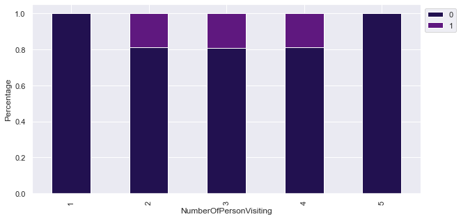

```python
#Total number of persons planning to take the trip with the customer
stacked_plot(data.NumberOfPersonVisiting)
```

- Customers who plan to take between 2-4 persons with them during travel, close to 20% have bought a travel package product.
- all Customers with 1 and 5 comapanions, did not purchase any product.
- the products dont seem either appealing or beneficial to the customers of the above two categories. This area needs further investigation

```
ProdTaken     0    1   All
CityTier
1          2592  506  3098
2           146   42   188
3          1115  346  1461
All        3853  894  4747
------------------------------------------------------------------------------------------------------------------------
```

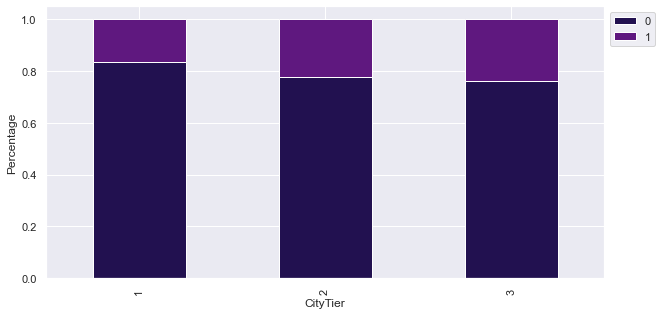

```python
stacked_plot(data.CityTier)
```

- most customers are from tier 2 and 3 have bought the packages

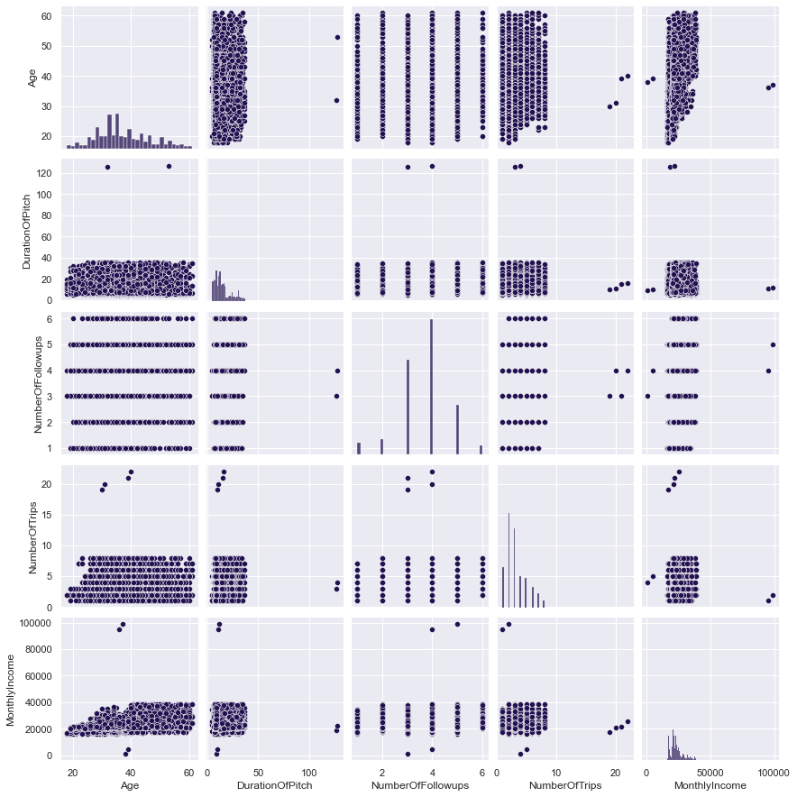

```python
#pairplot to plot pairwise relationships between variables
sns.pairplot(data=data);
```

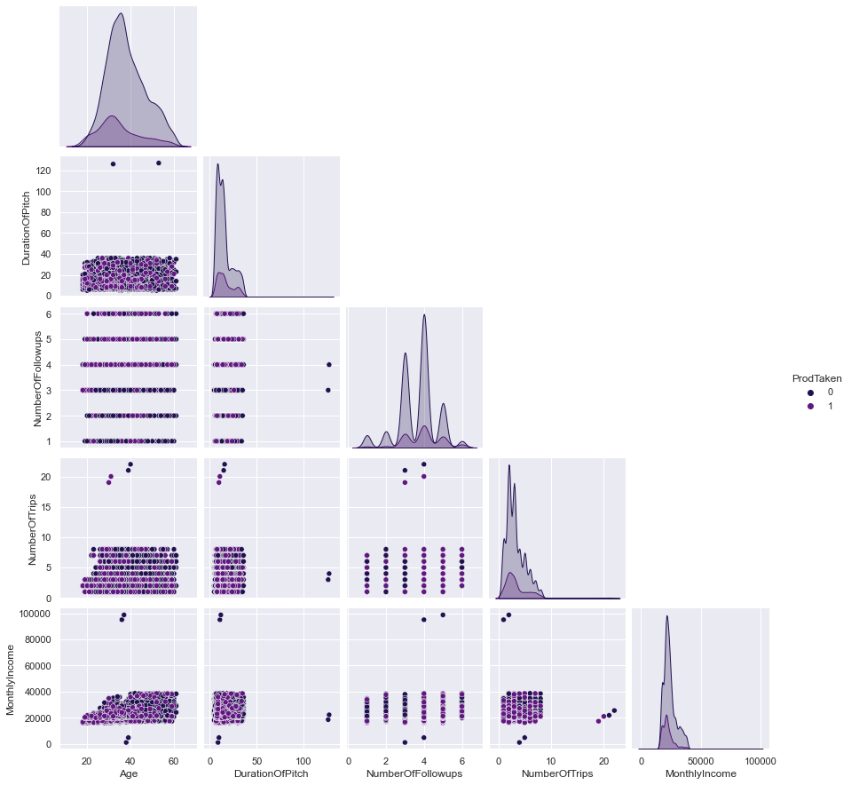

```python
sns.pairplot(data, hue="ProdTaken",corner=True)
plt.show()
```

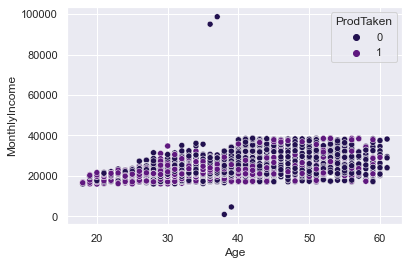

```python
sns.scatterplot(data=data, y='MonthlyIncome',x='Age',hue='ProdTaken')
```

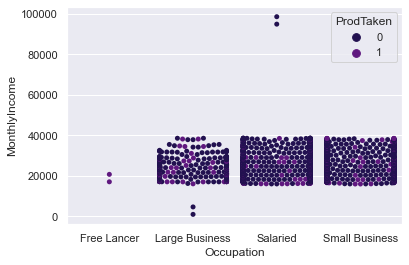

```python
sns.swarmplot(data=data, y='MonthlyIncome',x='Occupation',hue='ProdTaken')
```

### AGE

```python
data['Agebin'] = pd.cut(data['Age'], bins = [15,25, 31, 40, 50, 70], labels = ['15-25','26-30', '31-40', '41-50', '51-70'])
```

```python
data.Agebin.value_counts()
```

```
31-40    1890
41-50    1038
26-30     941
51-70     532
15-25     346
Name: Agebin, dtype: int64
```

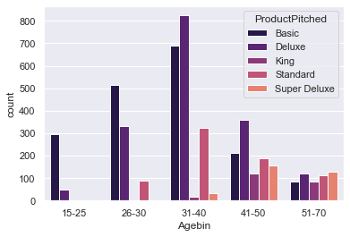

```python
sns.countplot(x='Agebin',hue='ProductPitched',data=data);
```

### Occupation

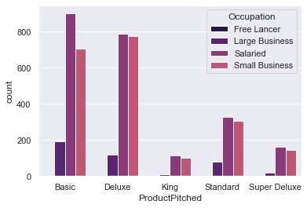

```python
sns.countplot(x="ProductPitched", data=data,  hue="Occupation");
```

### Gender

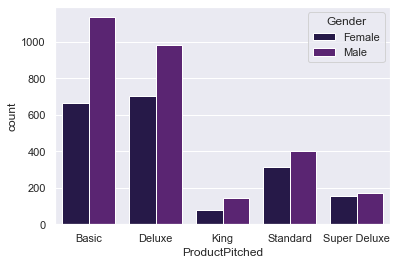

```python
sns.countplot(x="ProductPitched", data=data,  hue="Gender");
```

### Marital status

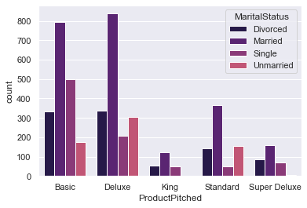

```python
sns.countplot(x="ProductPitched", data=data,  hue="MaritalStatus");
```

### Monthly Income

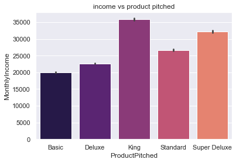

```python
plt.title('income vs product pitched')
sns.barplot(y='MonthlyIncome',x='ProductPitched',data=data);
```

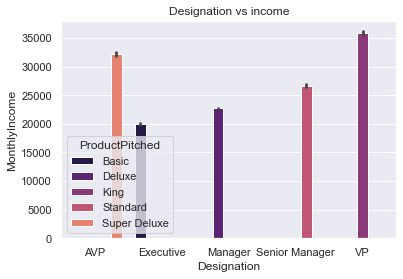

```python
plt.title('Designation vs income')
sns.barplot(x='Designation',y='MonthlyIncome',data=data ,hue='ProductPitched');
```

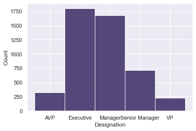

```python
sns.histplot(x='Designation',data=data);
```

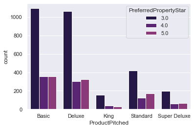

```python
sns.countplot(x="ProductPitched", data=data,  hue="PreferredPropertyStar");
```

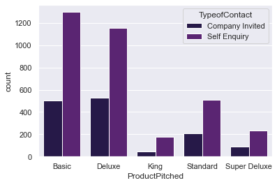

```python
sns.countplot(x="ProductPitched", data=data,  hue="TypeofContact");
```

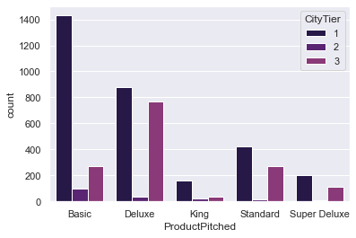

```python
sns.countplot(x="ProductPitched", data=data,  hue="CityTier");
```

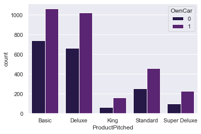

```python
sns.countplot(x="ProductPitched", data=data,  hue="OwnCar");
```

## profile of the customers

### other exploratory deep dive

- FreeLancers have very little data
- Large Business owners have higher chance of purchasing the travel package
- More Customers who had passport bought the product.
- Most of the customers who bought the product were Executive and manager
- Single and unmarried people has a lower chance of purchasing the travel package.

### outlier detection without treatment

I'll be only detecting outliers and not treating cause its not necessary as we are building decision trees

```python
Q1 = data.quantile(0.25)
Q3 = data.quantile(0.75)

IQR = Q3 - Q1

lower=Q1-1.5*IQR
upper=Q3+1.5*IQR
```

```python
outlier_num = data.select_dtypes(include=np.number)
```

```python
((outlier_num<lower)|(outlier_num>upper)).sum()/len(data)*100
```

```
Age                  0.000000
DurationOfPitch      2.275121
NumberOfFollowups    6.530440
NumberOfTrips        2.232989
MonthlyIncome        7.710133
dtype: float64
```

- numberoffollowups and mothlyincome have the most outliers compared to durationofpitch and numberoftrips
- age has no outlier
- Decision Trees are not sensitive to noisy data or outliers since extreme values or outliers never cause much reduction in the (RSS)
- There is n need for outlier treatment

## Data Preprocessing

### Data Preparation for Modeling

```python
X= data.drop(['ProdTaken','PitchSatisfactionScore','ProductPitched','NumberOfFollowups','DurationOfPitch'],axis=1)
y= data['ProdTaken']
```

```python
X = pd.get_dummies(X, drop_first=True)
# Splitting data into training and test set:
X_train,X_test, y_train, y_test =train_test_split(X,y, test_size=0.3, random_state=1, stratify=y)
print(X_train.shape,X_test.shape)
```

```
(3322, 32) (1425, 32)
```

```python
y.value_counts(1)
```

```
0    0.811671
1    0.188329
Name: ProdTaken, dtype: float64
```

## Model evaluation criterion

**The model can make wrong predictions as:**

1. Predicting a customer is likely to buy a travel package when he doesnt buy
2. Predicting a customer wont buy a travel package and he actually buys it

**Which metric to optimize?**

- We would want F1-Score to be maximized, the greater the F1-Score higher the chances of predicting both the classes correctly To predict which customer is more likely to purchase the newly introduced travel package.

```python
# defining a function to compute different metrics to check performance of a classification model built using sklearn
def model_performance_classification_sklearn(model, predictors, target):
    """
    Function to compute different metrics to check classification model performance

    model: classifier
    predictors: independent variables
    target: dependent variable
    """

    # predicting using the independent variables
    pred = model.predict(predictors)

    acc = accuracy_score(target, pred)  # to compute Accuracy
    recall = recall_score(target, pred)  # to compute Recall
    precision = precision_score(target, pred)  # to compute Precision
    f1 = f1_score(target, pred)  # to compute F1-score

    # creating a dataframe of metrics
    df_perf = pd.DataFrame(
        {
            "Accuracy": acc,
            "Recall": recall,
            "Precision": precision,
            "F1": f1,
        },
        index=[0],
    )

    return df_perf
```

```python
def confusion_matrix_sklearn(model, predictors, target):
    """
    To plot the confusion_matrix with percentages

    model: classifier
    predictors: independent variables
    target: dependent variable
    """
    y_pred = model.predict(predictors)
    cm = confusion_matrix(target, y_pred)
    labels = np.asarray(
        [
            ["{0:0.0f}".format(item) + "\n{0:.2%}".format(item / cm.flatten().sum())]
            for item in cm.flatten()
        ]
    ).reshape(2, 2)

    plt.figure(figsize=(6, 4))
    sns.heatmap(cm, annot=labels, fmt="")
    plt.ylabel("True label")
    plt.xlabel("Predicted label")
```

## Decision Tree - Model Building and Hyperparameter Tuning

### Decision Tree

```
Training performance:
    Accuracy  Recall  Precision   F1
0       1.0     1.0        1.0  1.0
Testing performance:
    Accuracy    Recall  Precision        F1
0  0.864561  0.671642   0.631579  0.650995
```

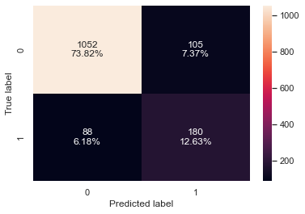

```python
#Fitting the model
d_tree = DecisionTreeClassifier(random_state=1)
d_tree.fit(X_train,y_train)

#Calculating different metrics
d_tree_model_train_perf=model_performance_classification_sklearn(d_tree,X_train,y_train)
print("Training performance:\n",d_tree_model_train_perf)
d_tree_model_test_perf=model_performance_classification_sklearn(d_tree,X_test,y_test)
print("Testing performance:\n",d_tree_model_test_perf)

#Creating confusion matrix
confusion_matrix_sklearn(d_tree,X_test,y_test)
```

- The decision tree is overfitting the training data.
- Let's try hyperparameter tuning and see if the model performance improves.

### Hyperparameter Tuning

```python
#Choose the type of classifier.
dtree_estimator = DecisionTreeClassifier(class_weight={0:0.18,1:0.72},random_state=1)

# Grid of parameters to choose from
parameters = {'max_depth': np.arange(2,30),
              'min_samples_leaf': [1, 2, 5, 7, 10],
              'max_leaf_nodes' : [2, 3, 5, 10,15],
              'min_impurity_decrease': [0.0001,0.001,0.01,0.1]
             }

# Type of scoring used to compare parameter combinations
scorer = metrics.make_scorer(metrics.f1_score)

# Run the grid search
grid_obj = GridSearchCV(dtree_estimator, parameters, scoring=scorer,n_jobs=-1)
grid_obj = grid_obj.fit(X_train, y_train)

# Set the clf to the best combination of parameters
dtree_estimator = grid_obj.best_estimator_

# Fit the best algorithm to the data.
dtree_estimator.fit(X_train, y_train)
```

```
DecisionTreeClassifier(class_weight={0: 0.18, 1: 0.72}, max_depth=4,
                       max_leaf_nodes=15, min_impurity_decrease=0.0001,
                       min_samples_leaf=10, random_state=1)
```

```
Training performance:
    Accuracy    Recall  Precision        F1
0  0.742023  0.702875    0.39604  0.506621
Testing performance:
    Accuracy    Recall  Precision        F1
0  0.712982  0.649254   0.355828  0.459709
```

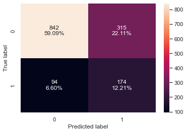

```python
#Calculating different metrics
dtree_estimator_model_train_perf=model_performance_classification_sklearn(dtree_estimator,X_train,y_train)
print("Training performance:\n",dtree_estimator_model_train_perf)
dtree_estimator_model_test_perf=model_performance_classification_sklearn(dtree_estimator,X_test,y_test)
print("Testing performance:\n",dtree_estimator_model_test_perf)

#Creating confusion matrix
confusion_matrix_sklearn(dtree_estimator,X_test,y_test)
```

- The overfitting has reduced but the test f1-score has also decreased.
- Let's try some other models.

## Bagging - Model Building and Hyperparameter Tuning

### Random Forest Classifier

```
Training performance:
    Accuracy  Recall  Precision   F1
0       1.0     1.0        1.0  1.0
Testing performance:
    Accuracy    Recall  Precision        F1
0  0.876491  0.421642   0.843284  0.562189
```

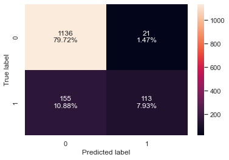

```python
#Fitting the model
rf_estimator = RandomForestClassifier(random_state=1)
rf_estimator.fit(X_train,y_train)

#Calculating different metrics
rf_estimator_model_train_perf=model_performance_classification_sklearn(rf_estimator,X_train,y_train)
print("Training performance:\n",rf_estimator_model_train_perf)
rf_estimator_model_test_perf=model_performance_classification_sklearn(rf_estimator,X_test,y_test)
print("Testing performance:\n",rf_estimator_model_test_perf)

#Creating confusion matrix
confusion_matrix_sklearn(rf_estimator,X_test,y_test)
```

### Hyperparameter Tuning

```python
# Choose the type of classifier.
rf_tuned = RandomForestClassifier(class_weight={0:0.18,1:0.82},random_state=1,oob_score=True,bootstrap=True)

parameters = {
                'max_depth': list(np.arange(5,30,5)) + [None],
                'max_features': ['sqrt','log2',None],
                'min_samples_leaf': np.arange(1,15,5),
                'min_samples_split': np.arange(2, 20, 5),
                'n_estimators': np.arange(10,110,10)}


# Type of scoring used to compare parameter combinations
scorer = metrics.make_scorer(metrics.f1_score)

# Run the grid search
grid_obj = GridSearchCV(rf_tuned, parameters, scoring=scorer, cv=5,n_jobs=-1)
grid_obj = grid_obj.fit(X_train, y_train)

# Set the clf to the best combination of parameters
rf_tuned = grid_obj.best_estimator_

# Fit the best algorithm to the data.
rf_tuned.fit(X_train, y_train)
```

```
RandomForestClassifier(class_weight={0: 0.18, 1: 0.82}, max_depth=15,
                       max_features=None, min_samples_split=7, n_estimators=60,
                       oob_score=True, random_state=1)
```

```
Training performance:
    Accuracy    Recall  Precision        F1
0  0.987959  0.988818   0.949387  0.968701
Testing performance:
    Accuracy    Recall  Precision        F1
0  0.877193  0.600746   0.703057  0.647887
```

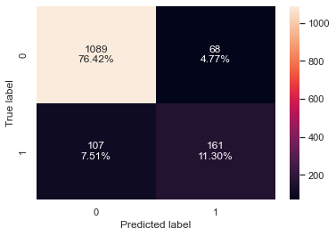

```python
#Calculating different metrics
rf_tuned_model_train_perf=model_performance_classification_sklearn(rf_tuned,X_train,y_train)
print("Training performance:\n",rf_tuned_model_train_perf)
rf_tuned_model_test_perf=model_performance_classification_sklearn(rf_tuned,X_test,y_test)
print("Testing performance:\n",rf_tuned_model_test_perf)

#Creating confusion matrix
confusion_matrix_sklearn(rf_tuned,X_test,y_test)
```

### Bagging Classifier

```
   Accuracy    Recall  Precision        F1
0  0.993679  0.971246    0.99509  0.983023
   Accuracy    Recall  Precision        F1
0      0.88  0.529851   0.759358  0.624176
```

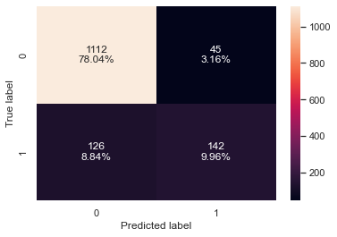

```python
#Fitting the model
bagging_classifier = BaggingClassifier(random_state=1)
bagging_classifier.fit(X_train,y_train)

#Calculating different metrics
bagging_classifier_model_train_perf=model_performance_classification_sklearn(bagging_classifier,X_train,y_train)
print(bagging_classifier_model_train_perf)
bagging_classifier_model_test_perf=model_performance_classification_sklearn(bagging_classifier,X_test,y_test)
print(bagging_classifier_model_test_perf)

#Creating confusion matrix
confusion_matrix_sklearn(bagging_classifier,X_test,y_test)
```

- Bagging classifier is overfitting the training data.
- Let's try hyperparameter tuning and see if the model performance improves.

### Hyperparameter Tuning

```python
# Choose the type of classifier.
bagging_estimator_tuned = BaggingClassifier(random_state=1)

# Grid of parameters to choose from
parameters = {'max_samples': [0.7,0.8,0.9,1],
              'max_features': [0.7,0.8,0.9,1],
              'n_estimators' : [10,20,30,40,50],
             }

# Type of scoring used to compare parameter combinations
scorer = metrics.make_scorer(metrics.f1_score)

# Run the grid search
grid_obj = GridSearchCV(bagging_estimator_tuned, parameters, scoring=scorer,cv=5)
grid_obj = grid_obj.fit(X_train, y_train)

# Set the clf to the best combination of parameters
bagging_estimator_tuned = grid_obj.best_estimator_

# Fit the best algorithm to the data.
bagging_estimator_tuned.fit(X_train, y_train)
```

```
BaggingClassifier(max_features=0.9, max_samples=0.9, n_estimators=50,
                  random_state=1)
```

```
   Accuracy    Recall  Precision      F1
0  0.999398  0.996805        1.0  0.9984
   Accuracy    Recall  Precision        F1
0  0.892632  0.552239    0.81768  0.659243
```

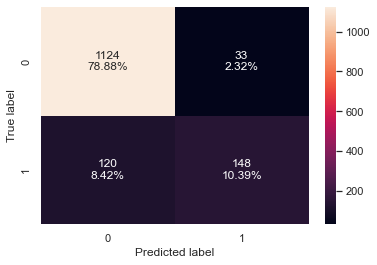

```python
#Calculating different metrics
bagging_estimator_tuned_model_train_perf=model_performance_classification_sklearn(bagging_estimator_tuned,X_train,y_train)
print(bagging_estimator_tuned_model_train_perf)
bagging_estimator_tuned_model_test_perf=model_performance_classification_sklearn(bagging_estimator_tuned,X_test,y_test)
print(bagging_estimator_tuned_model_test_perf)

#Creating confusion matrix
confusion_matrix_sklearn(bagging_estimator_tuned,X_test,y_test)
```

- the model performance has increased after hyperparameter tuning, but it still overfits

## Boosting - Model Building and Hyperparameter Tuning

### AdaBoost Classifier

```
   Accuracy    Recall  Precision        F1
0  0.843167  0.282748   0.710843  0.404571
   Accuracy    Recall  Precision        F1
0  0.832982  0.220149   0.670455  0.331461
```

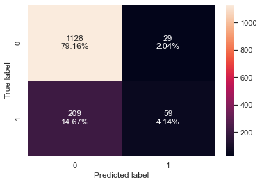

```python
#Fitting the model
ab_classifier = AdaBoostClassifier(random_state=1)
ab_classifier.fit(X_train,y_train)

#Calculating different metrics
ab_classifier_model_train_perf=model_performance_classification_sklearn(ab_classifier,X_train,y_train)
print(ab_classifier_model_train_perf)
ab_classifier_model_test_perf=model_performance_classification_sklearn(ab_classifier,X_test,y_test)
print(ab_classifier_model_test_perf)

#Creating confusion matrix
confusion_matrix_sklearn(ab_classifier,X_test,y_test)
```

- it does poorly on recall, but in general doesnt overfit
- F1 score is also too low

### Hyperparameter Tuning

- An AdaBoost classifier is a meta-estimator that begins by fitting a classifier on the original dataset and then fits additional copies of the classifier on the same dataset but where the weights of incorrectly classified instances are adjusted such that subsequent classifiers focus more on difficult cases.
- Some important hyperparamters are:
  - base_estimator: The base estimator from which the boosted ensemble is built. By default the base estimator is a decision tree with max_depth=1
  - n_estimators: The maximum number of estimators at which boosting is terminated. Default value is 50.
  - learning_rate: Learning rate shrinks the contribution of each classifier by learning_rate. There is a trade-off between learning_rate and n_estimators.

```python
# Choose the type of classifier.
abc_tuned = AdaBoostClassifier(random_state=1)

# Grid of parameters to choose from
parameters = {
    #Let's try different max_depth for base_estimator
    "base_estimator":[DecisionTreeClassifier(max_depth=1),DecisionTreeClassifier(max_depth=2),
                      DecisionTreeClassifier(max_depth=3)],
    "n_estimators": np.arange(10,110,10),
    "learning_rate":np.arange(0.1,2,0.1)
}

# Type of scoring used to compare parameter  combinations
scorer = metrics.make_scorer(metrics.f1_score)

# Run the grid search
grid_obj = GridSearchCV(abc_tuned, parameters, scoring=scorer,cv=5)
grid_obj = grid_obj.fit(X_train, y_train)

# Set the clf to the best combination of parameters
abc_tuned = grid_obj.best_estimator_

# Fit the best algorithm to the data.
abc_tuned.fit(X_train, y_train)
```

```
AdaBoostClassifier(base_estimator=DecisionTreeClassifier(max_depth=3),
                   learning_rate=1.1, n_estimators=100, random_state=1)
```

```
   Accuracy    Recall  Precision       F1
0  0.975015  0.896166   0.968912  0.93112
   Accuracy    Recall  Precision        F1
0  0.884211  0.589552   0.741784  0.656965
```

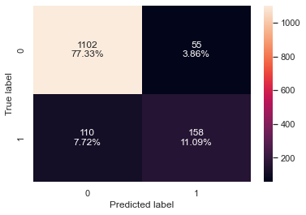

```python
#Calculating different metrics
abc_tuned_model_train_perf=model_performance_classification_sklearn(abc_tuned,X_train,y_train)
print(abc_tuned_model_train_perf)
abc_tuned_model_test_perf=model_performance_classification_sklearn(abc_tuned,X_test,y_test)
print(abc_tuned_model_test_perf)

#Creating confusion matrix
confusion_matrix_sklearn(abc_tuned,X_test,y_test)
```

- it still overfits but F1 score is way better

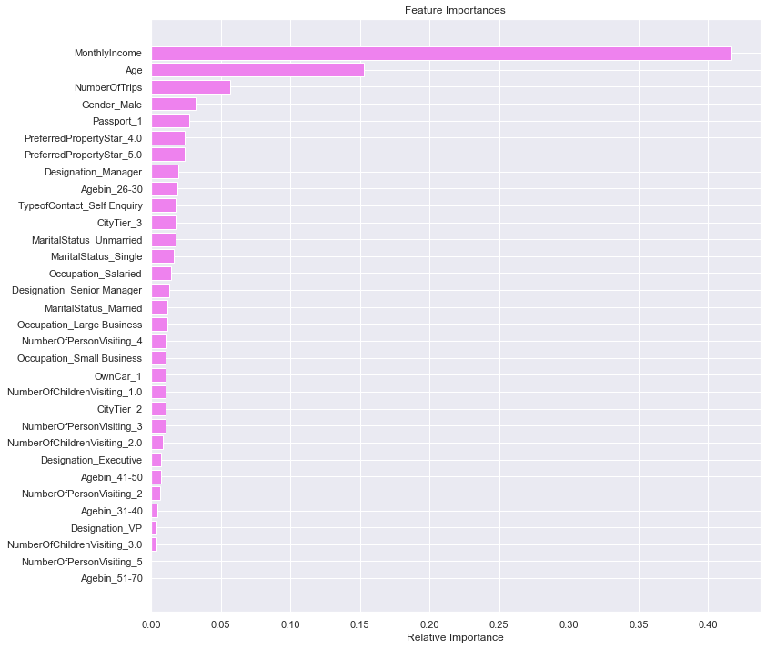

```python
importances = abc_tuned.feature_importances_
indices = np.argsort(importances)
feature_names = list(X.columns)

plt.figure(figsize=(12,12))
plt.title('Feature Importances')
plt.barh(range(len(indices)), importances[indices], color='violet', align='center')
plt.yticks(range(len(indices)), [feature_names[i] for i in indices])
plt.xlabel('Relative Importance')
plt.show()
```

### Gradient Boosting Classifier

```
Training performance:
    Accuracy    Recall  Precision        F1
0   0.87929  0.442492   0.841945  0.580105
Testing performance:
    Accuracy    Recall  Precision        F1
0  0.854737  0.365672   0.725926  0.486352
```

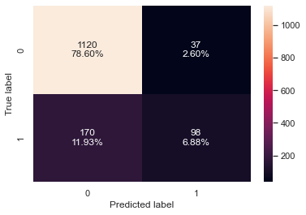

```python
#Fitting the model
gb_classifier = GradientBoostingClassifier(random_state=1)
gb_classifier.fit(X_train,y_train)

#Calculating different metrics
gb_classifier_model_train_perf=model_performance_classification_sklearn(gb_classifier,X_train,y_train)
print("Training performance:\n",gb_classifier_model_train_perf)
gb_classifier_model_test_perf=model_performance_classification_sklearn(gb_classifier,X_test,y_test)
print("Testing performance:\n",gb_classifier_model_test_perf)

#Creating confusion matrix
confusion_matrix_sklearn(gb_classifier,X_test,y_test)
```

- doesn't overfit but the performance isnt good

### Hyperparameter Tuning

```python
# Choose the type of classifier.
gbc_tuned = GradientBoostingClassifier(init=AdaBoostClassifier(random_state=1),random_state=1)

# Grid of parameters to choose from
parameters = {
    "n_estimators": [100,150,200,250],
    "subsample":[0.8,0.9,1],
    "max_features":[0.7,0.8,0.9,1]
}

# Type of scoring used to compare parameter combinations
scorer = metrics.make_scorer(metrics.f1_score)

# Run the grid search
grid_obj = GridSearchCV(gbc_tuned, parameters, scoring=scorer,cv=5)
grid_obj = grid_obj.fit(X_train, y_train)

# Set the clf to the best combination of parameters
gbc_tuned = grid_obj.best_estimator_

# Fit the best algorithm to the data.
gbc_tuned.fit(X_train, y_train)
```

```
GradientBoostingClassifier(init=AdaBoostClassifier(random_state=1),
                           max_features=0.8, n_estimators=250, random_state=1,
                           subsample=0.8)
```

```
Training performance:
    Accuracy   Recall  Precision        F1
0  0.910596  0.58147   0.912281  0.710244
Testing performance:
    Accuracy   Recall  Precision    F1
0  0.868772  0.44403   0.757962  0.56
```

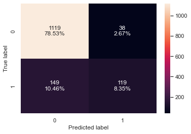

```python
#Calculating different metrics
gbc_tuned_model_train_perf=model_performance_classification_sklearn(gbc_tuned,X_train,y_train)
print("Training performance:\n",gbc_tuned_model_train_perf)
gbc_tuned_model_test_perf=model_performance_classification_sklearn(gbc_tuned,X_test,y_test)
print("Testing performance:\n",gbc_tuned_model_test_perf)

#Creating confusion matrix
confusion_matrix_sklearn(gbc_tuned,X_test,y_test)
```

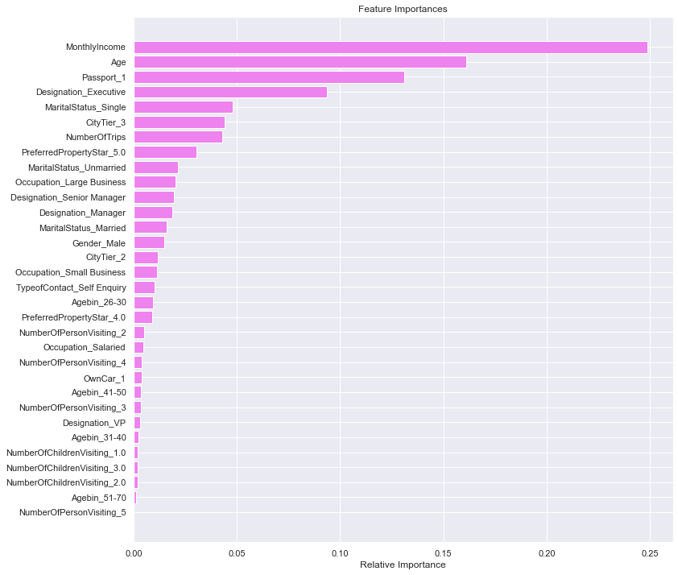

```python
importances = gbc_tuned.feature_importances_
indices = np.argsort(importances)
feature_names = list(X.columns)

plt.figure(figsize=(12,12))
plt.title('Feature Importances')
plt.barh(range(len(indices)), importances[indices], color='violet', align='center')
plt.yticks(range(len(indices)), [feature_names[i] for i in indices])
plt.xlabel('Relative Importance')
plt.show()
```

### XGBoost Classifier

```
Training performance:
    Accuracy    Recall  Precision        F1
0  0.997893  0.988818        1.0  0.994378
Testing performance:
    Accuracy   Recall  Precision        F1
0  0.905263  0.61194   0.841026  0.708423
```

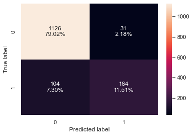

```python
#Fitting the model
xgb_classifier = XGBClassifier(random_state=1, eval_metric='logloss')
xgb_classifier.fit(X_train,y_train)

#Calculating different metrics
xgb_classifier_model_train_perf=model_performance_classification_sklearn(xgb_classifier,X_train,y_train)
print("Training performance:\n",xgb_classifier_model_train_perf)
xgb_classifier_model_test_perf=model_performance_classification_sklearn(xgb_classifier,X_test,y_test)
print("Testing performance:\n",xgb_classifier_model_test_perf)

#Creating confusion matrix
confusion_matrix_sklearn(xgb_classifier,X_test,y_test)
```

- xgboost classifier is overfitting the training data.
- Let's try hyperparameter tuning and see if the model performance improves.

### Hyperparameter Tuning

```python
# Choose the type of classifier.
xgb_tuned = XGBClassifier(random_state=1, eval_metric='logloss')

# Grid of parameters to choose from
parameters = {
    "n_estimators": [10,30,50],
    "scale_pos_weight":[1,2,5],
    "subsample":[0.7,0.9,1],
    "learning_rate":[0.05, 0.1,0.2],
    "colsample_bytree":[0.7,0.9,1],
    "colsample_bylevel":[0.5,0.7,1]
}

# Type of scoring used to compare parameter combinations
scorer = metrics.make_scorer(metrics.f1_score)

# Run the grid search
grid_obj = GridSearchCV(xgb_tuned, parameters,scoring=scorer,cv=5)
grid_obj = grid_obj.fit(X_train, y_train)

# Set the clf to the best combination of parameters
xgb_tuned = grid_obj.best_estimator_

# Fit the best algorithm to the data.
xgb_tuned.fit(X_train, y_train)
```

```
XGBClassifier(base_score=None, booster=None, callbacks=None,
              colsample_bylevel=1, colsample_bynode=None, colsample_bytree=1,
              early_stopping_rounds=None, enable_categorical=False,
              eval_metric='logloss', feature_types=None, gamma=None,
              gpu_id=None, grow_policy=None, importance_type=None,
              interaction_constraints=None, learning_rate=0.2, max_bin=None,
              max_cat_threshold=None, max_cat_to_onehot=None,
              max_delta_step=None, max_depth=None, max_leaves=None,
              min_child_weight=None, missing=nan, monotone_constraints=None,
              n_estimators=50, n_jobs=None, num_parallel_tree=None,
              predictor=None, random_state=1, ...)
```

```
Training performance:
    Accuracy   Recall  Precision        F1
0  0.966285  0.98722   0.855956  0.916914
Testing performance:
    Accuracy    Recall  Precision        F1
0  0.870877  0.738806   0.634615  0.682759
```

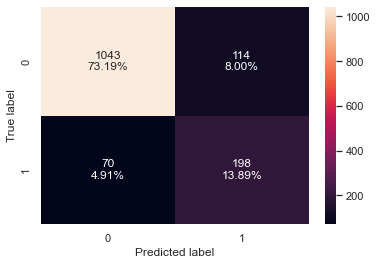

```python
#Calculating different metrics
xgb_tuned_model_train_perf=model_performance_classification_sklearn(xgb_tuned,X_train,y_train)
print("Training performance:\n",xgb_tuned_model_train_perf)
xgb_tuned_model_test_perf=model_performance_classification_sklearn(xgb_tuned,X_test,y_test)
print("Testing performance:\n",xgb_tuned_model_test_perf)

#Creating confusion matrix
confusion_matrix_sklearn(xgb_tuned,X_test,y_test)
```

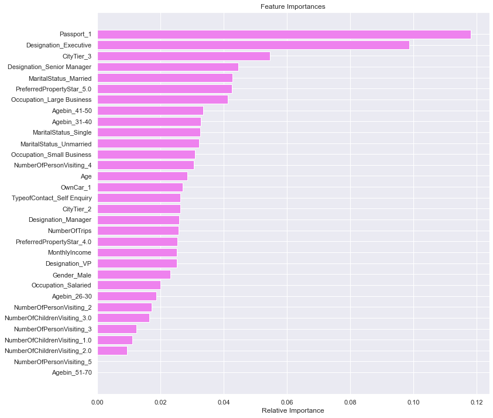

```python
importances = xgb_tuned.feature_importances_
indices = np.argsort(importances)
feature_names = list(X.columns)

plt.figure(figsize=(12,12))
plt.title('Feature Importances')
plt.barh(range(len(indices)), importances[indices], color='violet', align='center')
plt.yticks(range(len(indices)), [feature_names[i] for i in indices])
plt.xlabel('Relative Importance')
plt.show()
```

- The overfitting has reduced slightly but there is not much difference in the model performance.

## Stacking Model

```python
estimators = [('Random Forest',rf_tuned), ('Gradient Boosting',gbc_tuned), ('Decision Tree',dtree_estimator)]

final_estimator = xgb_tuned

stacking_classifier= StackingClassifier(estimators=estimators,final_estimator=final_estimator)

stacking_classifier.fit(X_train,y_train)
```

```
StackingClassifier(estimators=[('Random Forest',
                                RandomForestClassifier(class_weight={0: 0.18,
                                                                     1: 0.82},
                                                       max_depth=15,
                                                       max_features=None,
                                                       min_samples_split=7,
                                                       n_estimators=60,
                                                       oob_score=True,
                                                       random_state=1)),
                               ('Gradient Boosting',
                                GradientBoostingClassifier(init=AdaBoostClassifier(random_state=1),
                                                           max_features=0.8,
                                                           n_estimators=250,
                                                           random_state=1,
                                                           subsample=0.8)),...
                                                 gpu_id=None, grow_policy=None,
                                                 importance_type=None,
                                                 interaction_constraints=None,
                                                 learning_rate=0.2,
                                                 max_bin=None,
                                                 max_cat_threshold=None,
                                                 max_cat_to_onehot=None,
                                                 max_delta_step=None,
                                                 max_depth=None,
                                                 max_leaves=None,
                                                 min_child_weight=None,
                                                 missing=nan,
                                                 monotone_constraints=None,
                                                 n_estimators=50, n_jobs=None,
                                                 num_parallel_tree=None,
                                                 predictor=None, random_state=1, ...))
```

```
Training performance:
    Accuracy   Recall  Precision        F1
0  0.952739  0.99361   0.802581  0.887937
Testing performance:
    Accuracy    Recall  Precision        F1
0  0.851228  0.753731    0.58046  0.655844
```

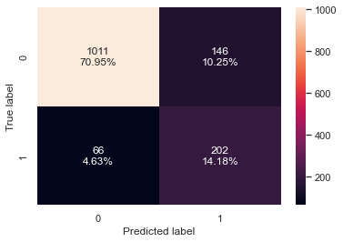

```python
#Calculating different metrics
stacking_classifier_model_train_perf=model_performance_classification_sklearn(stacking_classifier,X_train,y_train)
print("Training performance:\n",stacking_classifier_model_train_perf)
stacking_classifier_model_test_perf=model_performance_classification_sklearn(stacking_classifier,X_test,y_test)
print("Testing performance:\n",stacking_classifier_model_test_perf)

#Creating confusion matrix
confusion_matrix_sklearn(stacking_classifier,X_test,y_test)
```

## Comparing all models

```python
# training performance comparison

models_train_comp_df = pd.concat(
    [d_tree_model_train_perf.T,dtree_estimator_model_train_perf.T,rf_estimator_model_train_perf.T,rf_tuned_model_train_perf.T,
     bagging_classifier_model_train_perf.T,bagging_estimator_tuned_model_train_perf.T,ab_classifier_model_train_perf.T,
     abc_tuned_model_train_perf.T,gb_classifier_model_train_perf.T,gbc_tuned_model_train_perf.T,xgb_classifier_model_train_perf.T,
    xgb_tuned_model_train_perf.T,stacking_classifier_model_train_perf.T],
    axis=1,
)
models_train_comp_df.columns = [
    "Decision Tree",
    "Decision Tree Estimator",
    "Random Forest Estimator",
    "Random Forest Tuned",
    "Bagging Classifier",
    "Bagging Estimator Tuned",
    "Adaboost Classifier",
    "Adabosst Classifier Tuned",
    "Gradient Boost Classifier",
    "Gradient Boost Classifier Tuned",
    "XGBoost Classifier",
    "XGBoost Classifier Tuned",
    "Stacking Classifier"]
print("Training performance comparison:")
models_train_comp_df
```

```
Training performance comparison:
```

|  | Decision Tree | Decision Tree Estimator | Random Forest Estimator | Random Forest Tuned | Bagging Classifier | Bagging Estimator Tuned | Adaboost Classifier | Adabosst Classifier Tuned | Gradient Boost Classifier | Gradient Boost Classifier Tuned | XGBoost Classifier | XGBoost Classifier Tuned | Stacking Classifier |
| --- | --- | --- | --- | --- | --- | --- | --- | --- | --- | --- | --- | --- | --- |
| Accuracy | 1.0 | 0.742023 | 1.0 | 0.987959 | 0.993679 | 0.999398 | 0.843167 | 0.975015 | 0.879290 | 0.910596 | 0.997893 | 0.966285 | 0.952739 |
| Recall | 1.0 | 0.702875 | 1.0 | 0.988818 | 0.971246 | 0.996805 | 0.282748 | 0.896166 | 0.442492 | 0.581470 | 0.988818 | 0.987220 | 0.993610 |
| Precision | 1.0 | 0.396040 | 1.0 | 0.949387 | 0.995090 | 1.000000 | 0.710843 | 0.968912 | 0.841945 | 0.912281 | 1.000000 | 0.855956 | 0.802581 |
| F1 | 1.0 | 0.506621 | 1.0 | 0.968701 | 0.983023 | 0.998400 | 0.404571 | 0.931120 | 0.580105 | 0.710244 | 0.994378 | 0.916914 | 0.887937 |

```python
# testing performance comparison

models_test_comp_df = pd.concat(
    [d_tree_model_test_perf.T,dtree_estimator_model_test_perf.T,rf_estimator_model_test_perf.T,rf_tuned_model_test_perf.T,
     bagging_classifier_model_test_perf.T,bagging_estimator_tuned_model_test_perf.T,ab_classifier_model_test_perf.T,
     abc_tuned_model_test_perf.T,gb_classifier_model_test_perf.T,gbc_tuned_model_test_perf.T,xgb_classifier_model_test_perf.T,
    xgb_tuned_model_test_perf.T,stacking_classifier_model_test_perf.T],
    axis=1,
)
models_test_comp_df.columns = [
    "Decision Tree",
    "Decision Tree Estimator",
    "Random Forest Estimator",
    "Random Forest Tuned",
    "Bagging Classifier",
    "Bagging Estimator Tuned",
    "Adaboost Classifier",
    "Adabosst Classifier Tuned",
    "Gradient Boost Classifier",
    "Gradient Boost Classifier Tuned",
    "XGBoost Classifier",
    "XGBoost Classifier Tuned",
    "Stacking Classifier"]
print("Testing performance comparison:")
models_test_comp_df
```

```
Testing performance comparison:
```

|  | Decision Tree | Decision Tree Estimator | Random Forest Estimator | Random Forest Tuned | Bagging Classifier | Bagging Estimator Tuned | Adaboost Classifier | Adabosst Classifier Tuned | Gradient Boost Classifier | Gradient Boost Classifier Tuned | XGBoost Classifier | XGBoost Classifier Tuned | Stacking Classifier |
| --- | --- | --- | --- | --- | --- | --- | --- | --- | --- | --- | --- | --- | --- |
| Accuracy | 0.864561 | 0.712982 | 0.876491 | 0.877193 | 0.880000 | 0.892632 | 0.832982 | 0.884211 | 0.854737 | 0.868772 | 0.905263 | 0.870877 | 0.851228 |
| Recall | 0.671642 | 0.649254 | 0.421642 | 0.600746 | 0.529851 | 0.552239 | 0.220149 | 0.589552 | 0.365672 | 0.444030 | 0.611940 | 0.738806 | 0.753731 |
| Precision | 0.631579 | 0.355828 | 0.843284 | 0.703057 | 0.759358 | 0.817680 | 0.670455 | 0.741784 | 0.725926 | 0.757962 | 0.841026 | 0.634615 | 0.580460 |
| F1 | 0.650995 | 0.459709 | 0.562189 | 0.647887 | 0.624176 | 0.659243 | 0.331461 | 0.656965 | 0.486352 | 0.560000 | 0.708423 | 0.682759 | 0.655844 |

## Model performance observation

- The majority of the models are overfitting the training data in terms of f1-score.
- The XG boost classifier is giving the highest f1-score on the test data but is overfitting the training data.
- To get more generalized model, we can be look into tuning XGboost with different parameters.

## Model performance improvement

- xg boost classifier is the best for the model, it has a good F1 score compared to other models, and generally does better in other bagging and boosting techniques
- after tuning adaboost, it had way better performance than adaboost in Accuracy, precision, recall and f1 in both training and testing
- after tuning gradient boosting classifier by setting various parameters it gives a better result in Accuracy, precision, recall and f1 in both training and testing, to improve the model tuning no of estimators, maximum features, learning rate, max depth

## Insights, Conclusions and Recommendations

- some of the most important features include: meaning these people shoud be targeted
  - passport_1: those who have passport
  - designation_executive: those who are executives in their organization
  - citytier_3: those wh live in the higher developed areas
  - designation_senior manager: those who are senior managers in their organization
  - maritalstatus_married: those whoa re married
  - preferredpropertystar_5.0
  - occupation_large business
- key takeaways
  - Number of Childen, gender and Number of People visiting doesnt seem to have great impact on the prediction
  - basic and deluxe are the top 2 most purchased packages
  - young people are most likely to buy the packages
  - After identifying a potential customer, company should pitch packages per the customer's monthly incomes.
  - most customers were self inquired
  - ages 15-30 mostly bought basic package, 31-50 mostly Deluxe, 51-70 was a mixture of all but mostly deluxe and super deluxe
- To grow the business the company should:
  - encourage and enlighten customers on the need to get a passport
  - provide discounts and incentives to encourage people
  - pitch packages per the customer's monthly incomes.
  - target customers with Passport with special international packages